# Pandas: een inleiding

### K. Verbeeck, T. Vermeulen, J. Maervoet

Data Science (Theory) -- OGI02i

### De Pandas library

- Performante ondersteuning voor datamanipulatie en data-analyse
- Belangrijkste datastructuur: *DataFrame* (typisch tabulaire gelabelde data)
- Maakt gebruik van en integreert met NumPy (!)
- **[Getting Started](https://pandas.pydata.org/pandas-docs/stable/getting_started/index.html)** met **[10 minutes to Pandas](https://pandas.pydata.org/pandas-docs/stable/getting_started/10min.html)** en **[Basic Functionality](https://pandas.pydata.org/pandas-docs/stable/getting_started/basics.html)**
- **[tutorialpoint's Pandas Tutorial](https://www.tutorialspoint.com/python_pandas/index.htm)**

### Data Science context

- Hoe gaan we praktisch te werk? Methodologie ~ stappenplan
- Verschillende modellen

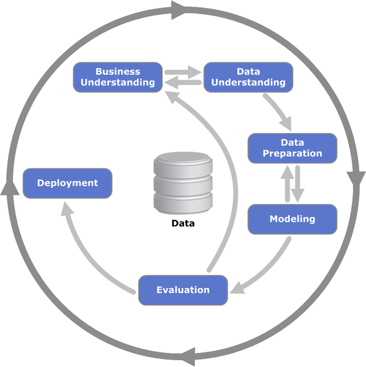

*Cross-industry standard process for data mining (CRISP-DM)*

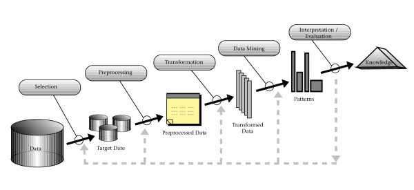

Uit: Usama Fayyad , Gregory Piatetsky-shapiro, Padhraic Smyth, **From Data Mining to Knowledge Discovery in Databases**, AI Magazine, vol. 17, p. 37--54, 1996

### Eenvoudige voorbeelden van de modeling

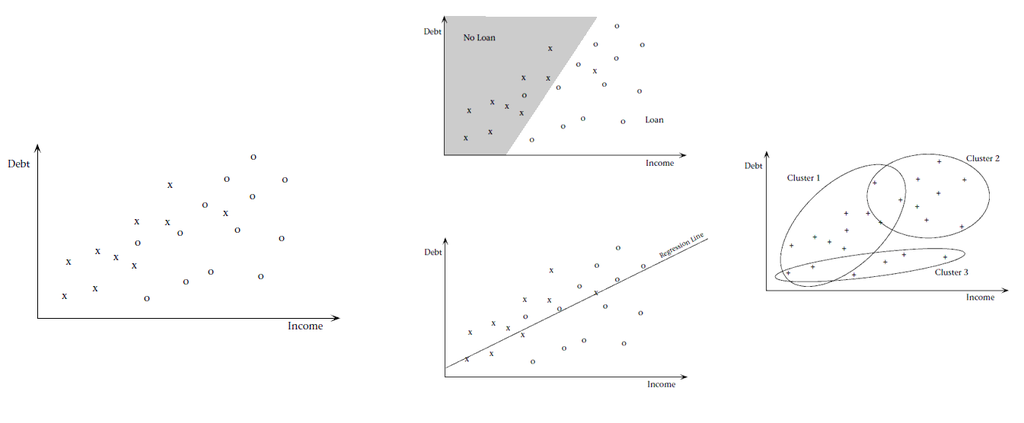

Dit geeft al een beeld van typische patronen die we kunnen ontdekken, maar een *echt* Data Science probleem vertrekt vanuit een case/vraag

### Waar kan Pandas nuttig zijn?

- Toch vooral in de stappen **Data Understanding** en **Data Preparation**
- Typische handelingen
  - Inladen van data (bv in tabelvorm)
  - Verkennen van ruwe data (ook descriptieve statistiek en visualiseren)
  - Subselecties maken in de data (bv feature selection)
  - Cleanen van data (bv behandelen missing values)
  - Combineren van data(sets)

### Datastructuren Pandas

### Datastructuur #1: Series

- 1-dimensionaal
- homogene data
- afmetingen niet manipuleerbaar
- as-namen: *index*

```python
import pandas as pd
data = ['a','b','c','d']
s = pd.Series(data) # je kan ook NumPy ndarrays gebruiken
print(s)
```

```
0    a
1    b
2    c
3    d
dtype: object
```

```python
s = pd.Series(data,index=[100,101,102,103])
print(s)
```

```
100    a
101    b
102    c
103    d
dtype: object
```

```python
dicti = {'a' : 0., 'b' : 1., 'c' : 2.}
s = pd.Series(dicti)
print(s)
```

```
a    0.0
b    1.0
c    2.0
dtype: float64
```

```python
s = pd.Series(dicti,index=['b','c','d','a'])
print(s)
print(s[0:2]) # enkel bij niet-numerieke indices
print(s['b'])
print(s[['a', 'b']])
```

```
b    1.0
c    2.0
d    NaN
a    0.0
dtype: float64
b    1.0
c    2.0
dtype: float64
1.0
a    0.0
b    1.0
dtype: float64
```

```python
s = pd.Series(5, index=[3, 4, 7, 8])
print(s)
```

```
3    5
4    5
7    5
8    5
dtype: int64
```

### Datastructuur #2: DataFrame

- 2-dimensionaal
- heterogene data
- ook afmetingen manipuleerbaar
- as-namen: *index*, *columns*

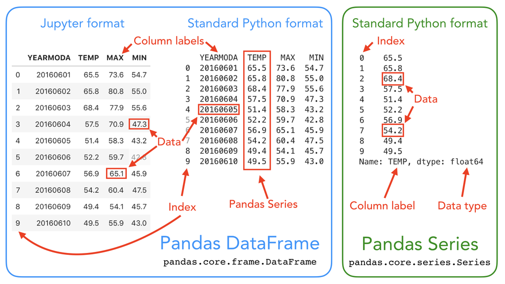

Bron: Geo-Python course, Department of Geosciences and Geography, University of Helsinki, https://geo-python.github.io/site/notebooks/L5/exploring-data-using-pandas.html

```python
import pandas as pd
data = {'Name':['Tom', 'Jack', 'Steve', 'Ricky'],'Age':[28,34,29,42]}
# je kan ook Pandas Series en NumPy ndarrays gebruiken
df = pd.DataFrame(data)
df
```

|  | Name | Age |
| --- | --- | --- |
| 0 | Tom | 28 |
| 1 | Jack | 34 |
| 2 | Steve | 29 |
| 3 | Ricky | 42 |

```python
data = [{'a': 1, 'b': 2}, {'a': 5, 'b': 10, 'c': 20}]
df = pd.DataFrame(data)
df
```

|  | a | b | c |
| --- | --- | --- | --- |
| 0 | 1 | 2 | NaN |
| 1 | 5 | 10 | 20.0 |

```python
data = [{'a': 1, 'b': 2}, {'a': 5, 'b': 10, 'c': 20}]

# index = rij-labels (moet overeenkomen met aantal rijen data)
# columns = kolom-labels (kan gebruikt worden voor selectie)
df = pd.DataFrame(data, index=['first', 'second'], columns=['a', 'b', 'd'])
df
```

|  | a | b | d |
| --- | --- | --- | --- |
| first | 1 | 2 | NaN |
| second | 5 | 10 | NaN |

```python
# kolom-manipulatie
print(df['a'])
df['c'] = [5, 6]
print(df)
df['d'] = df['a'] + df['b']
print(df)

del df['d'] # kolom verwijderen
print(df.pop('c')) # kolom 'poppen'
```

```
first     1
second    5
Name: a, dtype: int64
        a   b   d  c
first   1   2 NaN  5
second  5  10 NaN  6
        a   b   d  c
first   1   2   3  5
second  5  10  15  6
first     5
second    6
Name: c, dtype: int64
```

```python
# rij-manipulatie
df = pd.DataFrame([[1, 2], [3, 4]], columns=list('AB'))
df2 = pd.DataFrame([[5, 6], [7, 8]], columns=list('AB'))
df3 = df.append(df2)
df3
```

|  | A | B |
| --- | --- | --- |
| 0 | 1 | 2 |
| 1 | 3 | 4 |
| 0 | 5 | 6 |
| 1 | 7 | 8 |

```python
df3 = df3.drop(0)
df3
```

|  | A | B |
| --- | --- | --- |
| 1 | 3 | 4 |
| 1 | 7 | 8 |

```python
df = pd.DataFrame([[1, 2], [3, 4]], columns=list('AB'))
df2 = pd.DataFrame([[5, 6], [7, 8]], columns=list('AB'))
df3 = df.append(df2, ignore_index=True) # beïnvloedt df niet !!
df3
```

|  | A | B |
| --- | --- | --- |
| 0 | 1 | 2 |
| 1 | 3 | 4 |
| 2 | 5 | 6 |
| 3 | 7 | 8 |

```python
# loc: indexing en slicing met labels
# iloc: indexing en slicing met index-getallen

df3.loc[1:] # slicing with unique row labels
```

|  | A | B |
| --- | --- | --- |
| 1 | 3 | 4 |
| 2 | 5 | 6 |
| 3 | 7 | 8 |

```python
print(df.loc[1, 'A'])
df.iloc[0,0] = 666
df
```

```
3
```

|  | A | B |
| --- | --- | --- |
| 0 | 666 | 2 |
| 1 | 3 | 4 |

### Datastructuur #3: ...

- Deprecated: Panel (3-dimensionaal, heterogene data)
- Nu: MultiIndex (hierarchical indexing)

```python
import pandas as pd
import numpy as np

# voorbeeld met impliciete constructie

lijst = [['2ICT1']*2+['2ICT2']*2, ['Jan', 'Piet', 'Joris', 'Corneel']]

df = pd.DataFrame(np.random.randn(4, 4), index=lijst)
df
```

|  |  | 0 | 1 | 2 | 3 |
| --- | --- | --- | --- | --- | --- |
| 2ICT1 | Jan | -0.200173 | -2.618094 | 0.311782 | -0.857786 |
|  | Piet | 1.246275 | -0.773913 | 1.500000 | 0.642329 |
| 2ICT2 | Joris | 0.453619 | -1.825758 | -1.238000 | 1.648338 |
|  | Corneel | 0.186985 | 0.449799 | -0.348852 | -1.445006 |

### Data verkennen en verwerken met Pandas: een eerste opwarmer

Bron: Geo-Python course, Department of Geosciences and Geography, University of Helsinki, https://geo-python.github.io/site/notebooks/L5/exploring-data-using-pandas.html

#### Kumpula-June-2016-w-metadata.txt

`# Data file contents: Daily temperatures (mean, min, max) for Kumpula, Helsinki`  
`# for June 1-30, 2016`  
`# Data source: https://www.ncdc.noaa.gov/cdo-web/search?datasetid=GHCND`  
`# Data processing: Extracted temperatures from raw data file, converted to`  
`# comma-separated format`  
`#`  
`# David Whipp - 02.10.2017`  
`YEARMODA,TEMP,MAX,MIN`  
`20160601,65.5,73.6,54.7`  
`20160602,65.8,80.8,55.0`  
`20160603,68.4,,55.6`  
`...`

```python
import pandas as pd

# Read the file using pandas
data = pd.read_csv('Kumpula-June-2016-w-metadata.txt', skiprows=8)
data.head()
```

|  | YEARMODA | TEMP | MAX | MIN |
| --- | --- | --- | --- | --- |
| 0 | 20160601 | 65.5 | 73.6 | 54.7 |
| 1 | 20160602 | 65.8 | 80.8 | 55.0 |
| 2 | 20160603 | 68.4 | NaN | 55.6 |
| 3 | 20160604 | 57.5 | 70.9 | 47.3 |
| 4 | 20160605 | 51.4 | 58.3 | 43.2 |

```python
data.tail(3)
```

|  | YEARMODA | TEMP | MAX | MIN |
| --- | --- | --- | --- | --- |
| 27 | 20160628 | 65.4 | 73.0 | 55.8 |
| 28 | 20160629 | 65.8 | 73.2 | NaN |
| 29 | 20160630 | 65.7 | 72.7 | 59.2 |

```python
print(len(data))
print(data.shape)
print(data.columns.values)
print(data.index)
```

```
30
(30, 4)
['YEARMODA' 'TEMP' 'MAX' 'MIN']
RangeIndex(start=0, stop=30, step=1)
```

```python
selection = data[['YEARMODA','TEMP']]
print(selection.head())

# Each column (and each row) in a pandas data frame is actually a pandas Series
print(type(data['TEMP']))
```

```
   YEARMODA  TEMP
0  20160601  65.5
1  20160602  65.8
2  20160603  68.4
3  20160604  57.5
4  20160605  51.4
<class 'pandas.core.series.Series'>
```

```python
# Descriptive statistics
# use mean(), median(), min(), max(), and std() on any series

print(data['TEMP'].mean())
print(data.mean())
```

```
59.73
YEARMODA    2.016062e+07
TEMP        5.973000e+01
MAX         6.804074e+01
MIN         5.125714e+01
dtype: float64
```

```python
data.describe()
```

|  | YEARMODA | TEMP | MAX | MIN |
| --- | --- | --- | --- | --- |
| count | 3.000000e+01 | 30.000000 | 27.000000 | 28.000000 |
| mean | 2.016062e+07 | 59.730000 | 68.040741 | 51.257143 |
| std | 8.803408e+00 | 5.475472 | 6.505575 | 5.498985 |
| min | 2.016060e+07 | 49.400000 | 54.100000 | 41.700000 |
| 25% | 2.016061e+07 | 56.450000 | 64.650000 | 46.975000 |
| 50% | 2.016062e+07 | 60.050000 | 69.100000 | 53.100000 |
| 75% | 2.016062e+07 | 64.900000 | 72.050000 | 55.600000 |
| max | 2.016063e+07 | 69.600000 | 80.800000 | 60.300000 |

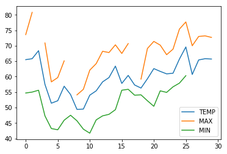

```python
# Basic plots

data[["TEMP", "MAX", "MIN"]].plot()
```

```python
# Calculate max min difference
data['DIFF'] = data['MAX'] - data['MIN']

# Check the result
data.head()
```

|  | YEARMODA | TEMP | MAX | MIN | DIFF |
| --- | --- | --- | --- | --- | --- |
| 0 | 20160601 | 65.5 | 73.6 | 54.7 | 18.9 |
| 1 | 20160602 | 65.8 | 80.8 | 55.0 | 25.8 |
| 2 | 20160603 | 68.4 | NaN | 55.6 | NaN |
| 3 | 20160604 | 57.5 | 70.9 | 47.3 | 23.6 |
| 4 | 20160605 | 51.4 | 58.3 | 43.2 | 15.1 |

```python
# Filtering and updating data
data['TEMP_CELSIUS'] = (data['TEMP'] - 32) / (9/5)
warm_temps = data.loc[data['TEMP_CELSIUS'] > 15]
warm_temps.head()
```

|  | YEARMODA | TEMP | MAX | MIN | DIFF | TEMP_CELSIUS |
| --- | --- | --- | --- | --- | --- | --- |
| 0 | 20160601 | 65.5 | 73.6 | 54.7 | 18.9 | 18.611111 |
| 1 | 20160602 | 65.8 | 80.8 | 55.0 | 25.8 | 18.777778 |
| 2 | 20160603 | 68.4 | NaN | 55.6 | NaN | 20.222222 |
| 13 | 20160614 | 59.7 | 67.8 | 47.8 | 20.0 | 15.388889 |
| 14 | 20160615 | 63.4 | 70.3 | 49.3 | 21.0 | 17.444444 |

```python
# Select rows with temp celsius higher than 15 degrees from late June 2016
warm_temps = data.loc[(data['TEMP_CELSIUS'] > 15) & (data['YEARMODA'] >= 20160615)]
# boolean indexing: | for or, & for and, ~ for not
warm_temps.head()
```

|  | YEARMODA | TEMP | MAX | MIN | DIFF | TEMP_CELSIUS |
| --- | --- | --- | --- | --- | --- | --- |
| 14 | 20160615 | 63.4 | 70.3 | 49.3 | 21.0 | 17.444444 |
| 16 | 20160617 | 60.4 | 70.7 | 55.9 | 14.8 | 15.777778 |
| 19 | 20160620 | 59.3 | 69.1 | 52.2 | 16.9 | 15.166667 |
| 20 | 20160621 | 62.6 | 71.4 | 50.4 | 21.0 | 17.000000 |
| 21 | 20160622 | 61.7 | 70.2 | 55.4 | 14.8 | 16.500000 |

```python
warm_temps.reset_index(drop=True, inplace=True)
 # drop -> drop the old index in stead of adding a separate index column
 # inplace -> modify the current data frame
warm_temps.head(12)
```

|  | YEARMODA | TEMP | MAX | MIN | DIFF | TEMP_CELSIUS |
| --- | --- | --- | --- | --- | --- | --- |
| 0 | 20160615 | 63.4 | 70.3 | 49.3 | 21.0 | 17.444444 |
| 1 | 20160617 | 60.4 | 70.7 | 55.9 | 14.8 | 15.777778 |
| 2 | 20160620 | 59.3 | 69.1 | 52.2 | 16.9 | 15.166667 |
| 3 | 20160621 | 62.6 | 71.4 | 50.4 | 21.0 | 17.000000 |
| 4 | 20160622 | 61.7 | 70.2 | 55.4 | 14.8 | 16.500000 |
| 5 | 20160623 | 60.9 | 67.1 | 54.9 | 12.2 | 16.055556 |
| 6 | 20160624 | 61.1 | 68.9 | 56.7 | 12.2 | 16.166667 |
| 7 | 20160625 | 65.7 | 75.4 | 57.9 | 17.5 | 18.722222 |
| 8 | 20160626 | 69.6 | 77.7 | 60.3 | 17.4 | 20.888889 |
| 9 | 20160627 | 60.7 | 70.0 | NaN | NaN | 15.944444 |
| 10 | 20160628 | 65.4 | 73.0 | 55.8 | 17.2 | 18.555556 |
| 11 | 20160629 | 65.8 | 73.2 | NaN | NaN | 18.777778 |

```python
# isna() detects NaN
# isnull() detects NaN, None, NaT
warm_temps.isna().head(12)
```

|  | YEARMODA | TEMP | MAX | MIN | DIFF | TEMP_CELSIUS |
| --- | --- | --- | --- | --- | --- | --- |
| 0 | False | False | False | False | False | False |
| 1 | False | False | False | False | False | False |
| 2 | False | False | False | False | False | False |
| 3 | False | False | False | False | False | False |
| 4 | False | False | False | False | False | False |
| 5 | False | False | False | False | False | False |
| 6 | False | False | False | False | False | False |
| 7 | False | False | False | False | False | False |
| 8 | False | False | False | False | False | False |
| 9 | False | False | False | True | True | False |
| 10 | False | False | False | False | False | False |
| 11 | False | False | False | True | True | False |

```python
# Drop no data values based on the MIN column
warm_temps.dropna(subset=['MIN']) # not an inplace operation
```

|  | YEARMODA | TEMP | MAX | MIN | DIFF | TEMP_CELSIUS |
| --- | --- | --- | --- | --- | --- | --- |
| 0 | 20160615 | 63.4 | 70.3 | 49.3 | 21.0 | 17.444444 |
| 1 | 20160617 | 60.4 | 70.7 | 55.9 | 14.8 | 15.777778 |
| 2 | 20160620 | 59.3 | 69.1 | 52.2 | 16.9 | 15.166667 |
| 3 | 20160621 | 62.6 | 71.4 | 50.4 | 21.0 | 17.000000 |
| 4 | 20160622 | 61.7 | 70.2 | 55.4 | 14.8 | 16.500000 |
| 5 | 20160623 | 60.9 | 67.1 | 54.9 | 12.2 | 16.055556 |
| 6 | 20160624 | 61.1 | 68.9 | 56.7 | 12.2 | 16.166667 |
| 7 | 20160625 | 65.7 | 75.4 | 57.9 | 17.5 | 18.722222 |
| 8 | 20160626 | 69.6 | 77.7 | 60.3 | 17.4 | 20.888889 |
| 10 | 20160628 | 65.4 | 73.0 | 55.8 | 17.2 | 18.555556 |
| 12 | 20160630 | 65.7 | 72.7 | 59.2 | 13.5 | 18.722222 |

```python
# Fill na values
warm_temps.fillna(-100) # not an inplace operation
```

|  | YEARMODA | TEMP | MAX | MIN | DIFF | TEMP_CELSIUS |
| --- | --- | --- | --- | --- | --- | --- |
| 0 | 20160615 | 63.4 | 70.3 | 49.3 | 21.0 | 17.444444 |
| 1 | 20160617 | 60.4 | 70.7 | 55.9 | 14.8 | 15.777778 |
| 2 | 20160620 | 59.3 | 69.1 | 52.2 | 16.9 | 15.166667 |
| 3 | 20160621 | 62.6 | 71.4 | 50.4 | 21.0 | 17.000000 |
| 4 | 20160622 | 61.7 | 70.2 | 55.4 | 14.8 | 16.500000 |
| 5 | 20160623 | 60.9 | 67.1 | 54.9 | 12.2 | 16.055556 |
| 6 | 20160624 | 61.1 | 68.9 | 56.7 | 12.2 | 16.166667 |
| 7 | 20160625 | 65.7 | 75.4 | 57.9 | 17.5 | 18.722222 |
| 8 | 20160626 | 69.6 | 77.7 | 60.3 | 17.4 | 20.888889 |
| 9 | 20160627 | 60.7 | 70.0 | -100.0 | -100.0 | 15.944444 |
| 10 | 20160628 | 65.4 | 73.0 | 55.8 | 17.2 | 18.555556 |
| 11 | 20160629 | 65.8 | 73.2 | -100.0 | -100.0 | 18.777778 |
| 12 | 20160630 | 65.7 | 72.7 | 59.2 | 13.5 | 18.722222 |

```python
# Data type conversions -- astype()

print("Truncated integer values:")
data['TEMP'].astype(int).head()
```

```
Truncated integer values:
```

```
0    65
1    65
2    68
3    57
4    51
Name: TEMP, dtype: int32
```

```python
print("Rounded integer values:")
print(data['TEMP'].round(0).astype(int).head())
```

```
Rounded integer values:
0    66
1    66
2    68
3    58
4    51
Name: TEMP, dtype: int32
```

```python
data['TEMP'].unique()
```

```
array([65.5, 65.8, 68.4, 57.5, 51.4, 52.2, 56.9, 54.2, 49.4, 49.5, 54. ,
       55.4, 58.3, 59.7, 63.4, 57.8, 60.4, 57.3, 56.3, 59.3, 62.6, 61.7,
       60.9, 61.1, 65.7, 69.6, 60.7, 65.4])
```

```python
data.sort_values(by='TEMP', ascending=False).head()
```

|  | YEARMODA | TEMP | MAX | MIN | DIFF | TEMP_CELSIUS |
| --- | --- | --- | --- | --- | --- | --- |
| 25 | 20160626 | 69.6 | 77.7 | 60.3 | 17.4 | 20.888889 |
| 2 | 20160603 | 68.4 | NaN | 55.6 | NaN | 20.222222 |
| 1 | 20160602 | 65.8 | 80.8 | 55.0 | 25.8 | 18.777778 |
| 28 | 20160629 | 65.8 | 73.2 | NaN | NaN | 18.777778 |
| 29 | 20160630 | 65.7 | 72.7 | 59.2 | 13.5 | 18.722222 |

### Let's take a look together …

- **[10 minutes to Pandas](https://pandas.pydata.org/pandas-docs/stable/getting_started/10min.html)**
- **[Pythonic Data Cleaning With NumPy and Pandas](https://realpython.com/python-data-cleaning-numpy-pandas/)**

`git clone https://github.com/realpython/python-data-cleaning.git`

Neem deze zaken écht door alvorens naar het labo te komen.

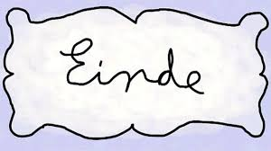